# Motorbike Market Analysis

**Melchizedek Ackah-Blay**

Motorbike Market Analysis

December 6, 2024

```python
import pandas as pd
import numpy as np
import matplotlib.pyplot as plt
import matplotlib.style as style
style.use('ggplot')
import seaborn as sns
```

import dataset

```python
df = pd.read_csv(r'/Users/melki/Desktop/europe-motorbikes-zenrows.csv')
```

looking at sample data

```python
df.sample(6)
```

|  | price | mileage | power | make_model | date | fuel | gear | offer_type | version | link |
| --- | --- | --- | --- | --- | --- | --- | --- | --- | --- | --- |
| 3164 | 11900 | 2001 | NaN | BMW R 1200 | 11/2018 | Gasoline | NaN | Used | nineT | /offers/bmw-r-1200-ninet-gasoline-white-4b3dbe... |
| 23704 | 16500 | 95000 | 118.0 | Honda Gold Wing | 03/2009 | Gasoline | Manual | Used | 1800 GL | /offers/honda-gold-wing-1800-gl-gasoline-red-2... |
| 12721 | 7000 | 26300 | 46.0 | Yamaha TMAX 530 | 04/2013 | Gasoline | NaN | Used | NaN | /offers/yamaha-tmax-530-gasoline-white-a0e0879... |
| 20683 | 3400 | 250 | 15.0 | Malaguti XSM | 03/2021 | Gasoline | Manual | Used | NaN | /offers/malaguti-xsm-gasoline-black-e8660fc7-4... |
| 2735 | 27900 | 4000 | 120.0 | Others | 12/2007 | Gasoline | NaN | Used | NaN | /offers/others-others-gasoline-orange-fcb517c3... |
| 24254 | 12500 | 1300 | 27.0 | Royal Enfield Bullet 500 | 10/2016 | Gasoline | Manual | Used | Gespann | /offers/royal-enfield-bullet-500-gespann-gasol... |

looking at the columns

```python
df.columns
```

```
Index(['price', 'mileage', 'power', 'make_model', 'date', 'fuel', 'gear',
       'offer_type', 'version', 'link'],
      dtype='object')
```

```python
len(df.columns)
```

```
10
```

looking at the size of the dataset

```python
df.shape
```

```
(34917, 10)
```

looking at general info of the dataset

```python
df.info()
```

```
<class 'pandas.core.frame.DataFrame'>
RangeIndex: 34917 entries, 0 to 34916
Data columns (total 10 columns):
 #   Column      Non-Null Count  Dtype
---  ------      --------------  -----
 0   price       34917 non-null  int64
 1   mileage     34917 non-null  int64
 2   power       28598 non-null  float64
 3   make_model  34917 non-null  object
 4   date        34917 non-null  object
 5   fuel        31727 non-null  object
 6   gear        12847 non-null  object
 7   offer_type  34917 non-null  object
 8   version     17413 non-null  object
 9   link        34917 non-null  object
dtypes: float64(1), int64(2), object(7)
memory usage: 2.7+ MB
```

looking at summary statistics

```python
df.describe()
```

|  | price | mileage | power |
| --- | --- | --- | --- |
| count | 3.491700e+04 | 3.491700e+04 | 28598.000000 |
| mean | 4.568532e+04 | 2.183175e+04 | 206.157598 |
| std | 4.850120e+06 | 2.059421e+05 | 9371.426465 |
| min | 1.000000e+00 | 0.000000e+00 | 1.000000 |
| 25% | 6.999000e+03 | 2.932000e+03 | 50.000000 |
| 50% | 9.920000e+03 | 1.100000e+04 | 90.000000 |
| 75% | 1.259000e+04 | 2.500000e+04 | 125.000000 |
| max | 8.888889e+08 | 9.999999e+06 | 913595.000000 |

changing values from scientific notation to full values

```python
pd.set_option('display.float_format', '{:.2f}'.format)
```

looking if it worked

```python
df.describe()
```

|  | price | mileage | power |
| --- | --- | --- | --- |
| count | 34917.00 | 34917.00 | 28598.00 |
| mean | 45685.32 | 21831.75 | 206.16 |
| std | 4850120.19 | 205942.09 | 9371.43 |
| min | 1.00 | 0.00 | 1.00 |
| 25% | 6999.00 | 2932.00 | 50.00 |
| 50% | 9920.00 | 11000.00 | 90.00 |
| 75% | 12590.00 | 25000.00 | 125.00 |
| max | 888888888.00 | 9999999.00 | 913595.00 |

looking at null values in the data

```python
df.isna().sum()
```

```
price             0
mileage           0
power          6319
make_model        0
date              0
fuel           3190
gear          22070
offer_type        0
version       17504
link              0
dtype: int64
```

addressing duplicates

```python
df.duplicated().sum()
```

```
5832
```

removing duplicates

```python
df.drop_duplicates(inplace = True)
```

looking at the new size of the dataset

```python
df.shape
```

```
(29085, 10)
```

**DATA EXPLORATION**

*motorbikes analysis*

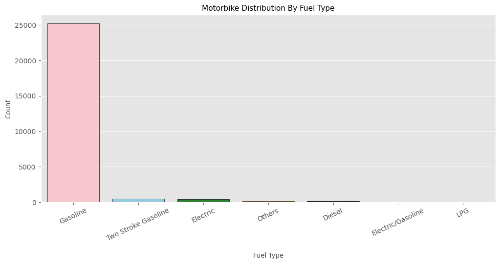

```python
import warnings
warnings.filterwarnings('ignore')

plt.figure(figsize = (12, 5))
sns.countplot(x = df['fuel'], palette = ['pink','skyblue', 'forestgreen', 'orange', 'black', 'navy', 'red'], edgecolor = 'black')
plt.title('Motorbike Distribution By Fuel Type', fontsize = 11)
plt.xlabel('\nFuel Type', fontsize = 9.5)
plt.xticks(rotation = 25)
plt.ylabel('Count', fontsize = 9.5)
plt.show()
```

*price and fuel type analysis*

```python
price_fuel = df.groupby('fuel')['price'].mean().sort_values(ascending = False)
price_fuel
```

```
fuel
LPG                   5003124.50
Diesel                 163621.05
Gasoline                57857.77
Others                   9453.84
Electric                 6202.65
Electric/Gasoline        6037.38
Two Stroke Gasoline      3713.34
Name: price, dtype: float64
```

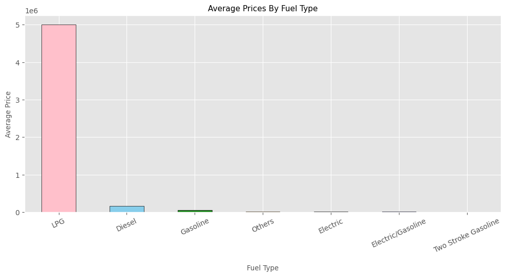

```python
plt.figure(figsize = (12, 5))
price_fuel.plot(kind = 'bar', color = ['pink','skyblue', 'forestgreen', 'orange', 'black', 'navy', 'red'], edgecolor = 'black')
plt.title('Average Prices By Fuel Type', fontsize = 11)
plt.xlabel('\nFuel Type', fontsize = 9.5)
plt.xticks(rotation = 25)
plt.ylabel('Average Price', fontsize = 9.5)
plt.show()
```

*offer type analysis*

```python
offer_type = pd.DataFrame(df['offer_type'].value_counts(normalize = True))
offer_type
```

| offer_type | proportion |
| --- | --- |
| Used | 0.90 |
| New | 0.06 |
| Demonstration | 0.02 |
| Pre-registered | 0.01 |
| Antique / Classic | 0.01 |

*make_model analysis and price analysis*

```python
model_price = df.groupby('make_model')['price'].mean().sort_values(ascending = False)
model_price
```

```
make_model
SYM SYMNH X                  148149748.00
EBR RS                       123456789.00
Honda ATC 125                  9999999.00
Kawasaki 400 S3                9999999.00
Harley-Davidson Café Racer     5008749.50
                                 ...
Alfa Scooters City                  90.00
Aprilia Sportcity 200               50.00
Suzuki Katana 50                    50.00
Husaberg FE 550                     50.00
Dnepr MT 10                          2.00
Name: price, Length: 2168, dtype: float64
```

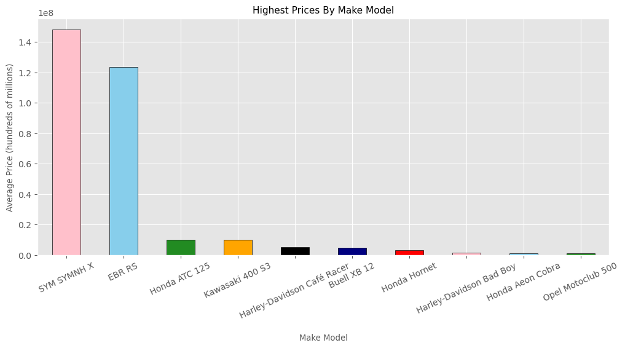

```python
plt.figure(figsize = (12, 5))
model_price.head(10).plot(kind = 'bar', color = ['pink','skyblue', 'forestgreen', 'orange', 'black', 'navy', 'red'], edgecolor = 'black')
plt.title('Highest Prices By Make Model', fontsize = 11)
plt.xlabel('\nMake Model', fontsize = 9.5)
plt.xticks(rotation = 25)
plt.ylabel('Average Price (hundreds of millions)', fontsize = 9.5)
plt.show()
```

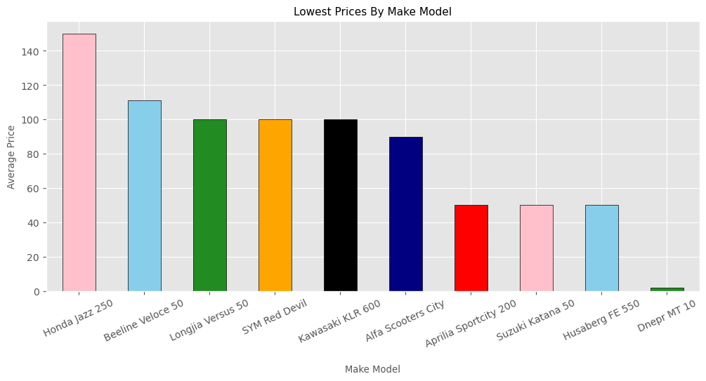

```python
plt.figure(figsize = (12, 5))
model_price.tail(10).plot(kind = 'bar', color = ['pink','skyblue', 'forestgreen', 'orange', 'black', 'navy', 'red'], edgecolor = 'black')
plt.title('Lowest Prices By Make Model', fontsize = 11)
plt.xlabel('\nMake Model', fontsize = 9.5)
plt.xticks(rotation = 25)
plt.ylabel('Average Price', fontsize = 9.5)
plt.show()
```

*offer type and power analysis*

```python
offer_power = df.groupby('offer_type')['power'].mean().sort_values(ascending = False)
offer_power
```

```
offer_type
Used                146.49
Demonstration       106.60
New                  97.29
Pre-registered       76.10
Antique / Classic    42.60
Name: power, dtype: float64
```

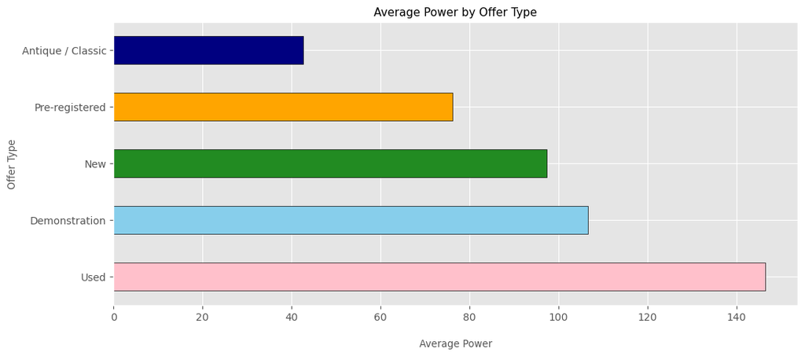

```python
plt.figure(figsize = (12, 5))
offer_power.plot(kind = 'barh', color = ['pink','skyblue', 'forestgreen', 'orange', 'navy', 'red'], edgecolor = 'black')
plt.title('Average Power by Offer Type', fontsize = 11)
plt.xlabel('\nAverage Power', fontsize = 9.5)
plt.ylabel('Offer Type', fontsize = 9.5)
plt.show()
```

gear, offer type, and price analysis

```python
gear_offer_price = df.groupby(['offer_type', 'gear'])['price'].mean().sort_values(ascending = False).unstack()
gear_offer_price
```

| gear offer_type | Automatic | Manual | Semi-automatic |
| --- | --- | --- | --- |
| Antique / Classic | NaN | 19254.00 | NaN |
| Demonstration | 11675.91 | 15944.75 | 17648.33 |
| New | 14707.27 | 21760.05 | NaN |
| Pre-registered | 5801.20 | 11907.11 | 19790.00 |
| Used | 10423.09 | 159058.80 | 13567.40 |

*analyzing motorbikes based on offer type and gear*

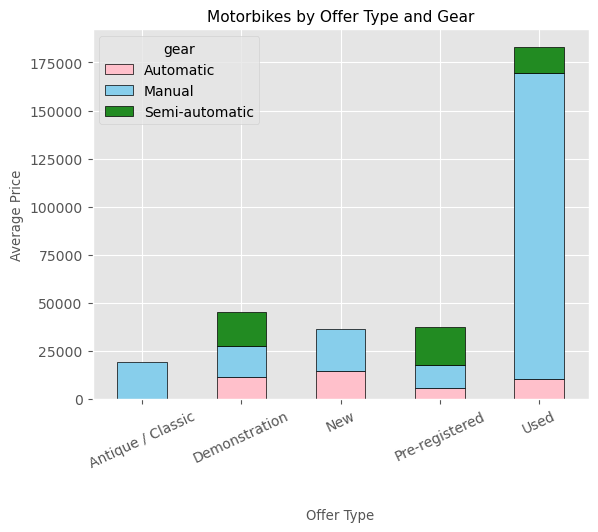

```python
gear_offer_price.plot(kind = 'bar', stacked = True, color = ['pink','skyblue', 'forestgreen', 'orange', 'navy', 'red'], edgecolor = 'black')
plt.title('Motorbikes by Offer Type and Gear', fontsize = 11)
plt.ylabel('Average Price', fontsize = 9.5)
plt.xticks(rotation = 25)
plt.xlabel('\n\nOffer Type', fontsize = 9.5)
plt.show()
```

*fuel distribution analysis*

```python
fuel_dist = df['fuel'].value_counts()
fuel_dist
```

```
fuel
Gasoline               25181
Two Stroke Gasoline      469
Electric                 374
Others                   148
Diesel                   132
Electric/Gasoline          8
LPG                        2
Name: count, dtype: int64
```

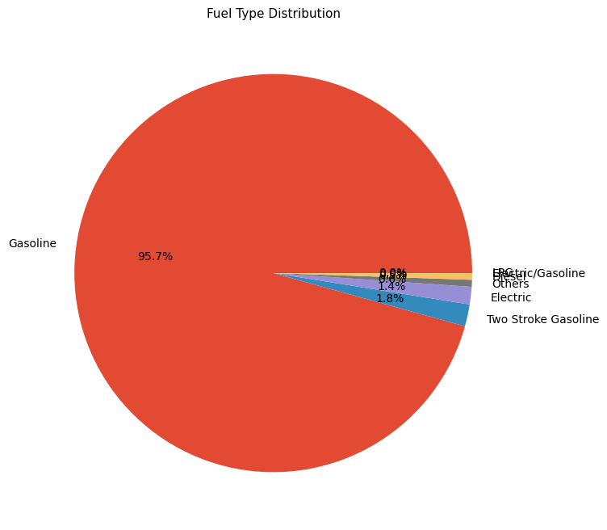

```python
plt.figure(figsize = (20, 8))
fuel_dist.plot(kind = 'pie', labels = fuel_dist.index, autopct = '%1.1f%%')
plt.title('Fuel Type Distribution', fontsize = 11)
plt.ylabel('')
plt.show()
```

*analyzing mileage and price*

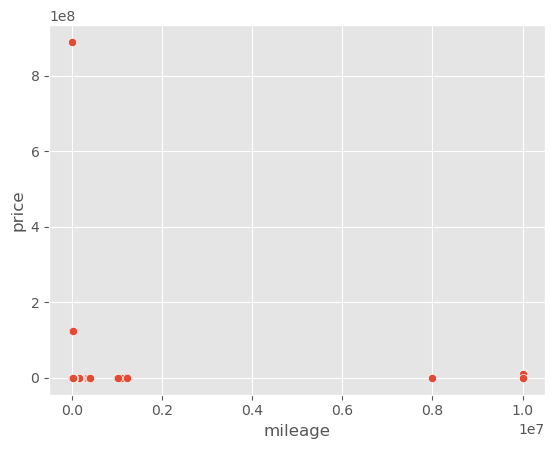

```python
sns.scatterplot(x = 'mileage', y = 'price', data = df, marker = 'o')
plt.show()
```

**FEATURE ENGINEERING**

```python
df.dropna(inplace = True)
x = df[['mileage', 'fuel', 'power', 'offer_type', 'gear']]
y = df['price']
```

*label encoding x variables*

```python
from sklearn.preprocessing import LabelEncoder
encoder = LabelEncoder()

x['gear'] = encoder.fit_transform(x['gear'])
x['offer_type'] = encoder.fit_transform(x['offer_type'])
x['fuel'] = encoder.fit_transform(x['fuel'])
```

*verifying if the encoding worked*

```python
x.sample(3)
```

|  | mileage | fuel | power | offer_type | gear |
| --- | --- | --- | --- | --- | --- |
| 14333 | 2500 | 4 | 109.00 | 1 | 1 |
| 23686 | 11300 | 3 | 116.00 | 4 | 1 |
| 2134 | 5700 | 3 | 145.00 | 4 | 1 |

*scaling the x values to be in a uniform range*

```python
from sklearn.preprocessing import StandardScaler
scaler = StandardScaler()
x_scaled = scaler.fit_transform(x)
```

*splitting data into train and test data*

```python
from sklearn.model_selection import train_test_split as t
x_train, x_test, y_train, y_test = t(x_scaled, y, test_size = 0.2, random_state = 1)
```

*creating function to evaluate model*

```python
from sklearn.metrics import mean_squared_error, mean_absolute_error, r2_score
import math
def evaluator(pred):
    print(f'mean squared error: {round(mean_squared_error(y_test, pred), 6)}')
    print(f'root mean squared error: {round(math.sqrt(mean_squared_error(y_test, pred)),6)}')
    print(f'mean absolute error: {round(mean_absolute_error(y_test, pred), 6)}')
    print(f'adjusted r squared: {round(r2_score(y_test, pred), 6)}')
```

*training with a linear regression model*

```python
from sklearn.linear_model import LinearRegression
lin_mod = LinearRegression()
lin_mod.fit(x_train, y_train)
lin_pred = lin_mod.predict(x_test)
```

*evaluating model*

```python
evaluator(lin_pred)
```

```
mean squared error: 72264872231.71042
root mean squared error: 268821.264471
mean absolute error: 223299.988883
adjusted r squared: -28.21214
```

*training with support vector machine*

```python
from sklearn.svm import SVR
from sklearn.model_selection import GridSearchCV
p1 = {
    'C':[0.01, 0.5, 0.1],
    'kernel':['linear', 'rbf', 'poky']
}
gridSVR = GridSearchCV(SVR(), param_grid = p1)
gridSVR.fit(x_train, y_train)
```

```
GridSearchCV(estimator=SVR(),
             param_grid={'C': [0.01, 0.5, 0.1],
                         'kernel': ['linear', 'rbf', 'poky']})
```

*evaluating model*

```python
svr_pred = gridSVR.predict(x_test)
evaluator(svr_pred)
```

```
mean squared error: 2490235196.061222
root mean squared error: 49902.256423
mean absolute error: 8133.600315
adjusted r squared: -0.006645
```

*looking at the model's best parameters*

```python
gridSVR.best_params_
```

```
{'C': 0.01, 'kernel': 'linear'}
```

*training with random forest regressor*

```python
from sklearn.ensemble import RandomForestRegressor
from sklearn.model_selection import GridSearchCV
p2 = {
    'n_estimators': [45, 50, 150],
    'min_samples_split': [None, 2, 5]
}
gridRF = GridSearchCV(RandomForestRegressor(), param_grid = p2)
gridRF.fit(x_train, y_train)
rf_pred = gridRF.predict(x_test)
```

*evaluating model*

```python
evaluator(rf_pred)
```

```
mean squared error: 487254586344045.8
root mean squared error: 22073843.941281
mean absolute error: 946912.304727
adjusted r squared: -196965.364109
```

*looking at the model's best parameters*

```python
gridRF.best_params_
```

```
{'min_samples_split': 5, 'n_estimators': 45}
```

*training xgboost regressor*

```python
from xgboost import XGBRegressor
from sklearn.model_selection import GridSearchCV
p3 = {
    'n_estimators': [45, 50, 65, 150],
    'learning_rate': [0.001, 0.01, 0.1],
    'min_child_weight': [None, 0.5, 1]
}
gridXGR = GridSearchCV(XGBRegressor(), param_grid = p3)
gridXGR.fit(x_train, y_train)
xg_pred = gridXGR.predict(x_test)
```

*evaluating model*

```python
evaluator(xg_pred)
```

```
mean squared error: 369356144951.5121
root mean squared error: 607746.776998
mean absolute error: 217554.738656
adjusted r squared: -148.307444
```

*looking at the model's best parameters*

```python
gridXGR.best_params_
```

```
{'learning_rate': 0.001, 'min_child_weight': None, 'n_estimators': 45}
```

```python
from sklearn.inspection import permutation_importance

# Assuming you have a fitted model and validation data
perm_importance = permutation_importance(gridSVR, x, y, scoring='neg_mean_squared_error')

# Display feature importance
for i, imp in enumerate(perm_importance.importances_mean):
    print(f"Feature {i}: {imp}")
```

```
Feature 0: -1109431193.109375
Feature 1: 97.20625
Feature 2: -33887134.646875
Feature 3: -1116237.54375
Feature 4: -12490.6375
```

**MODEL CONCLUSION**

So **fuel type** is the feature with the most importance to price of a motorbike which makes sense because most riders have some form of gas bikes and are not ready to switch to any form of electric bikes.

At a closer look at the data, electric bikes were not that popular in the motorbike market

The feature that came in second by a considerably wide margin from the first is the **gear type** of the car. Majority of bikers in everyday life ride a manual and it would take quite some time for them to switch over to semi-automatic or fully automatic bikes

My takeaway from this project with regard to Motorbike sales is to prioritize the fuel type and the gear type in order to make more sales. Specifically, you should aim at having significantly more **gas based** and **manual** motorbikes at the dealership, shop or on the website where you sell your motorbikes. Doing these will ensure you reach your revenue and profit quotas!